# Project 1 – Advanced Data Exploration & Data Wrangling

Alex Wolff

2024-04-13

## Load Packages

```r
library(tidyverse)
library(kableExtra)
library(nycflights13)
options(scipen=999)
```

# Part 1

## Load Data 1

```r
bike_data <- dn <- read_csv("/home/ballengerb@ad.wlu.edu/BUS_317_01/wolffa24/Data/bike_share_day.csv")
```

## Question 1

```r
bike_data <- bike_data %>%
  rename(index=instant,
         date = dteday,
         year = yr,
         month = mnth,
         ftemp = atemp,
         humidity = hum,
         casual_cnt = casual,
         registered_cnt = registered,
         total_count = cnt)
```

```r
bike_data %>%
    head(50) %>%
    kable() %>%
    kable_styling() %>%
    scroll_box(width = "100%", height = "400px")
```

| index | date | season | year | month | holiday | weekday | workingday | weathersit | temp | ftemp | humidity | windspeed | casual_cnt | registered_cnt | total_count |
| --- | --- | --- | --- | --- | --- | --- | --- | --- | --- | --- | --- | --- | --- | --- | --- |
| 1 | 1/1/11 | 1 | 0 | 1 | 0 | 6 | 0 | 2 | 0.3441670 | 0.3636250 | 0.805833 | 0.1604460 | 331 | 654 | 985 |
| 2 | 1/2/11 | 1 | 0 | 1 | 0 | 0 | 0 | 2 | 0.3634780 | 0.3537390 | 0.696087 | 0.2485390 | 131 | 670 | 801 |
| 3 | 1/3/11 | 1 | 0 | 1 | 0 | 1 | 1 | 1 | 0.1963640 | 0.1894050 | 0.437273 | 0.2483090 | 120 | 1229 | 1349 |
| 4 | 1/4/11 | 1 | 0 | 1 | 0 | 2 | 1 | 1 | 0.2000000 | 0.2121220 | 0.590435 | 0.1602960 | 108 | 1454 | 1562 |
| 5 | 1/5/11 | 1 | 0 | 1 | 0 | 3 | 1 | 1 | 0.2269570 | 0.2292700 | 0.436957 | 0.1869000 | 82 | 1518 | 1600 |
| 6 | 1/6/11 | 1 | 0 | 1 | 0 | 4 | 1 | 1 | 0.2043480 | 0.2332090 | 0.518261 | 0.0895652 | 88 | 1518 | 1606 |
| 7 | 1/7/11 | 1 | 0 | 1 | 0 | 5 | 1 | 2 | 0.1965220 | 0.2088390 | 0.498696 | 0.1687260 | 148 | 1362 | 1510 |
| 8 | 1/8/11 | 1 | 0 | 1 | 0 | 6 | 0 | 2 | 0.1650000 | 0.1622540 | 0.535833 | 0.2668040 | 68 | 891 | 959 |
| 9 | 1/9/11 | 1 | 0 | 1 | 0 | 0 | 0 | 1 | 0.1383330 | 0.1161750 | 0.434167 | 0.3619500 | 54 | 768 | 822 |
| 10 | 1/10/11 | 1 | 0 | 1 | 0 | 1 | 1 | 1 | 0.1508330 | 0.1508880 | 0.482917 | 0.2232670 | 41 | 1280 | 1321 |
| 11 | 1/11/11 | 1 | 0 | 1 | 0 | 2 | 1 | 2 | 0.1690910 | 0.1914640 | 0.686364 | 0.1221320 | 43 | 1220 | 1263 |
| 12 | 1/12/11 | 1 | 0 | 1 | 0 | 3 | 1 | 1 | 0.1727270 | 0.1604730 | 0.599545 | 0.3046270 | 25 | 1137 | 1162 |
| 13 | 1/13/11 | 1 | 0 | 1 | 0 | 4 | 1 | 1 | 0.1650000 | 0.1508830 | 0.470417 | 0.3010000 | 38 | 1368 | 1406 |
| 14 | 1/14/11 | 1 | 0 | 1 | 0 | 5 | 1 | 1 | 0.1608700 | 0.1884130 | 0.537826 | 0.1265480 | 54 | 1367 | 1421 |
| 15 | 1/15/11 | 1 | 0 | 1 | 0 | 6 | 0 | 2 | 0.2333330 | 0.2481120 | 0.498750 | 0.1579630 | 222 | 1026 | 1248 |
| 16 | 1/16/11 | 1 | 0 | 1 | 0 | 0 | 0 | 1 | 0.2316670 | 0.2342170 | 0.483750 | 0.1884330 | 251 | 953 | 1204 |
| 17 | 1/17/11 | 1 | 0 | 1 | 1 | 1 | 0 | 2 | 0.1758330 | 0.1767710 | 0.537500 | 0.1940170 | 117 | 883 | 1000 |
| 18 | 1/18/11 | 1 | 0 | 1 | 0 | 2 | 1 | 2 | 0.2166670 | 0.2323330 | 0.861667 | 0.1467750 | 9 | 674 | 683 |
| 19 | 1/19/11 | 1 | 0 | 1 | 0 | 3 | 1 | 2 | 0.2921740 | 0.2984220 | 0.741739 | 0.2083170 | 78 | 1572 | 1650 |
| 20 | 1/20/11 | 1 | 0 | 1 | 0 | 4 | 1 | 2 | 0.2616670 | 0.2550500 | 0.538333 | 0.1959040 | 83 | 1844 | 1927 |
| 21 | 1/21/11 | 1 | 0 | 1 | 0 | 5 | 1 | 1 | 0.1775000 | 0.1578330 | 0.457083 | 0.3532420 | 75 | 1468 | 1543 |
| 22 | 1/22/11 | 1 | 0 | 1 | 0 | 6 | 0 | 1 | 0.0591304 | 0.0790696 | 0.400000 | 0.1719700 | 93 | 888 | 981 |
| 23 | 1/23/11 | 1 | 0 | 1 | 0 | 0 | 0 | 1 | 0.0965217 | 0.0988391 | 0.436522 | 0.2466000 | 150 | 836 | 986 |
| 24 | 1/24/11 | 1 | 0 | 1 | 0 | 1 | 1 | 1 | 0.0973913 | 0.1179300 | 0.491739 | 0.1583300 | 86 | 1330 | 1416 |
| 25 | 1/25/11 | 1 | 0 | 1 | 0 | 2 | 1 | 2 | 0.2234780 | 0.2345260 | 0.616957 | 0.1297960 | 186 | 1799 | 1985 |
| 26 | 1/26/11 | 1 | 0 | 1 | 0 | 3 | 1 | 3 | 0.2175000 | 0.2036000 | 0.862500 | 0.2938500 | 34 | 472 | 506 |
| 27 | 1/27/11 | 1 | 0 | 1 | 0 | 4 | 1 | 1 | 0.1950000 | 0.2197000 | 0.687500 | 0.1138370 | 15 | 416 | 431 |
| 28 | 1/28/11 | 1 | 0 | 1 | 0 | 5 | 1 | 2 | 0.2034780 | 0.2233170 | 0.793043 | 0.1233000 | 38 | 1129 | 1167 |
| 29 | 1/29/11 | 1 | 0 | 1 | 0 | 6 | 0 | 1 | 0.1965220 | 0.2121260 | 0.651739 | 0.1453650 | 123 | 975 | 1098 |
| 30 | 1/30/11 | 1 | 0 | 1 | 0 | 0 | 0 | 1 | 0.2165220 | 0.2503220 | 0.722174 | 0.0739826 | 140 | 956 | 1096 |
| 31 | 1/31/11 | 1 | 0 | 1 | 0 | 1 | 1 | 2 | 0.1808330 | 0.1862500 | 0.603750 | 0.1871920 | 42 | 1459 | 1501 |
| 32 | 2/1/11 | 1 | 0 | 2 | 0 | 2 | 1 | 2 | 0.1921740 | 0.2345300 | 0.829565 | 0.0532130 | 47 | 1313 | 1360 |
| 33 | 2/2/11 | 1 | 0 | 2 | 0 | 3 | 1 | 2 | 0.2600000 | 0.2544170 | 0.775417 | 0.2643080 | 72 | 1454 | 1526 |
| 34 | 2/3/11 | 1 | 0 | 2 | 0 | 4 | 1 | 1 | 0.1869570 | 0.1778780 | 0.437826 | 0.2777520 | 61 | 1489 | 1550 |
| 35 | 2/4/11 | 1 | 0 | 2 | 0 | 5 | 1 | 2 | 0.2113040 | 0.2285870 | 0.585217 | 0.1278390 | 88 | 1620 | 1708 |
| 36 | 2/5/11 | 1 | 0 | 2 | 0 | 6 | 0 | 2 | 0.2333330 | 0.2430580 | 0.929167 | 0.1610790 | 100 | 905 | 1005 |
| 37 | 2/6/11 | 1 | 0 | 2 | 0 | 0 | 0 | 1 | 0.2858330 | 0.2916710 | 0.568333 | 0.1418000 | 354 | 1269 | 1623 |
| 38 | 2/7/11 | 1 | 0 | 2 | 0 | 1 | 1 | 1 | 0.2716670 | 0.3036580 | 0.738333 | 0.0454083 | 120 | 1592 | 1712 |
| 39 | 2/8/11 | 1 | 0 | 2 | 0 | 2 | 1 | 1 | 0.2208330 | 0.1982460 | 0.537917 | 0.3619500 | 64 | 1466 | 1530 |
| 40 | 2/9/11 | 1 | 0 | 2 | 0 | 3 | 1 | 2 | 0.1347830 | 0.1442830 | 0.494783 | 0.1888390 | 53 | 1552 | 1605 |
| 41 | 2/10/11 | 1 | 0 | 2 | 0 | 4 | 1 | 1 | 0.1443480 | 0.1495480 | 0.437391 | 0.2219350 | 47 | 1491 | 1538 |
| 42 | 2/11/11 | 1 | 0 | 2 | 0 | 5 | 1 | 1 | 0.1890910 | 0.2135090 | 0.506364 | 0.1085500 | 149 | 1597 | 1746 |
| 43 | 2/12/11 | 1 | 0 | 2 | 0 | 6 | 0 | 1 | 0.2225000 | 0.2329540 | 0.544167 | 0.2033670 | 288 | 1184 | 1472 |
| 44 | 2/13/11 | 1 | 0 | 2 | 0 | 0 | 0 | 1 | 0.3165220 | 0.3241130 | 0.457391 | 0.2608830 | 397 | 1192 | 1589 |
| 45 | 2/14/11 | 1 | 0 | 2 | 0 | 1 | 1 | 1 | 0.4150000 | 0.3983500 | 0.375833 | 0.4179080 | 208 | 1705 | 1913 |
| 46 | 2/15/11 | 1 | 0 | 2 | 0 | 2 | 1 | 1 | 0.2660870 | 0.2542740 | 0.314348 | 0.2913740 | 140 | 1675 | 1815 |
| 47 | 2/16/11 | 1 | 0 | 2 | 0 | 3 | 1 | 1 | 0.3182610 | 0.3162000 | 0.423478 | 0.2517910 | 218 | 1897 | 2115 |
| 48 | 2/17/11 | 1 | 0 | 2 | 0 | 4 | 1 | 1 | 0.4358330 | 0.4286580 | 0.505000 | 0.2301040 | 259 | 2216 | 2475 |
| 49 | 2/18/11 | 1 | 0 | 2 | 0 | 5 | 1 | 1 | 0.5216670 | 0.5119830 | 0.516667 | 0.2649250 | 579 | 2348 | 2927 |
| 50 | 2/19/11 | 1 | 0 | 2 | 0 | 6 | 0 | 1 | 0.3991670 | 0.3914040 | 0.187917 | 0.5074630 | 532 | 1103 | 1635 |

```r
eda <- function(df) {
  glimpse(df)
  summary(df)}

eda(bike_data)
```

```
## Rows: 731
## Columns: 16
## $ index          <dbl> 1, 2, 3, 4, 5, 6, 7, 8, 9, 10, 11, 12, 13, 14, 15, 16, …
## $ date           <chr> "1/1/11", "1/2/11", "1/3/11", "1/4/11", "1/5/11", "1/6/…
## $ season         <dbl> 1, 1, 1, 1, 1, 1, 1, 1, 1, 1, 1, 1, 1, 1, 1, 1, 1, 1, 1…
## $ year           <dbl> 0, 0, 0, 0, 0, 0, 0, 0, 0, 0, 0, 0, 0, 0, 0, 0, 0, 0, 0…
## $ month          <dbl> 1, 1, 1, 1, 1, 1, 1, 1, 1, 1, 1, 1, 1, 1, 1, 1, 1, 1, 1…
## $ holiday        <dbl> 0, 0, 0, 0, 0, 0, 0, 0, 0, 0, 0, 0, 0, 0, 0, 0, 1, 0, 0…
## $ weekday        <dbl> 6, 0, 1, 2, 3, 4, 5, 6, 0, 1, 2, 3, 4, 5, 6, 0, 1, 2, 3…
## $ workingday     <dbl> 0, 0, 1, 1, 1, 1, 1, 0, 0, 1, 1, 1, 1, 1, 0, 0, 0, 1, 1…
## $ weathersit     <dbl> 2, 2, 1, 1, 1, 1, 2, 2, 1, 1, 2, 1, 1, 1, 2, 1, 2, 2, 2…
## $ temp           <dbl> 0.3441670, 0.3634780, 0.1963640, 0.2000000, 0.2269570, …
## $ ftemp          <dbl> 0.3636250, 0.3537390, 0.1894050, 0.2121220, 0.2292700, …
## $ humidity       <dbl> 0.805833, 0.696087, 0.437273, 0.590435, 0.436957, 0.518…
## $ windspeed      <dbl> 0.1604460, 0.2485390, 0.2483090, 0.1602960, 0.1869000, …
## $ casual_cnt     <dbl> 331, 131, 120, 108, 82, 88, 148, 68, 54, 41, 43, 25, 38…
## $ registered_cnt <dbl> 654, 670, 1229, 1454, 1518, 1518, 1362, 891, 768, 1280,…
## $ total_count    <dbl> 985, 801, 1349, 1562, 1600, 1606, 1510, 959, 822, 1321,…
```

```
##      index           date               season           year
##  Min.   :  1.0   Length:731         Min.   :1.000   Min.   :0.0000
##  1st Qu.:183.5   Class :character   1st Qu.:2.000   1st Qu.:0.0000
##  Median :366.0   Mode  :character   Median :3.000   Median :1.0000
##  Mean   :366.0                      Mean   :2.497   Mean   :0.5007
##  3rd Qu.:548.5                      3rd Qu.:3.000   3rd Qu.:1.0000
##  Max.   :731.0                      Max.   :4.000   Max.   :1.0000
##      month          holiday           weekday        workingday
##  Min.   : 1.00   Min.   :0.00000   Min.   :0.000   Min.   :0.000
##  1st Qu.: 4.00   1st Qu.:0.00000   1st Qu.:1.000   1st Qu.:0.000
##  Median : 7.00   Median :0.00000   Median :3.000   Median :1.000
##  Mean   : 6.52   Mean   :0.02873   Mean   :2.997   Mean   :0.684
##  3rd Qu.:10.00   3rd Qu.:0.00000   3rd Qu.:5.000   3rd Qu.:1.000
##  Max.   :12.00   Max.   :1.00000   Max.   :6.000   Max.   :1.000
##    weathersit         temp             ftemp            humidity
##  Min.   :1.000   Min.   :0.05913   Min.   :0.07907   Min.   :0.0000
##  1st Qu.:1.000   1st Qu.:0.33708   1st Qu.:0.33784   1st Qu.:0.5200
##  Median :1.000   Median :0.49833   Median :0.48673   Median :0.6267
##  Mean   :1.395   Mean   :0.49538   Mean   :0.47435   Mean   :0.6279
##  3rd Qu.:2.000   3rd Qu.:0.65542   3rd Qu.:0.60860   3rd Qu.:0.7302
##  Max.   :3.000   Max.   :0.86167   Max.   :0.84090   Max.   :0.9725
##    windspeed         casual_cnt     registered_cnt  total_count
##  Min.   :0.02239   Min.   :   2.0   Min.   :  20   Min.   :  22
##  1st Qu.:0.13495   1st Qu.: 315.5   1st Qu.:2497   1st Qu.:3152
##  Median :0.18097   Median : 713.0   Median :3662   Median :4548
##  Mean   :0.19049   Mean   : 848.2   Mean   :3656   Mean   :4504
##  3rd Qu.:0.23321   3rd Qu.:1096.0   3rd Qu.:4776   3rd Qu.:5956
##  Max.   :0.50746   Max.   :3410.0   Max.   :6946   Max.   :8714
```

There are 0 missing observations.

## Question 2

```r
bike_data <- bike_data %>%
  mutate(
    season = factor(season,
                    levels = c(2, 3, 4, 1),
                    labels = c("spring",
                               "summer",
                               "fall",
                               "winter")),
    holiday = factor(holiday,
                     levels = c(0, 1),
                     labels = c("no",
                                "yes")),
    workingday = factor(workingday,
                        levels = c(0, 1),
                        labels = c("no",
                                   "yes")),
    year = factor(year,
                  levels = c(0, 1),
                  labels = c("2011",
                             "2012")),
    weathersit = factor(weathersit,
                        levels = c(1, 2, 3, 4),
                        labels = c("clear",
                                   "mist",
                                   "light precipitation",
                                   "heavy precipitation")))

bike_data %>%
  kable() %>%
  kable_styling() %>%
  scroll_box(width = "100%", height = "400px")
```

| index | date | season | year | month | holiday | weekday | workingday | weathersit | temp | ftemp | humidity | windspeed | casual_cnt | registered_cnt | total_count |
| --- | --- | --- | --- | --- | --- | --- | --- | --- | --- | --- | --- | --- | --- | --- | --- |
| 1 | 1/1/11 | winter | 2011 | 1 | no | 6 | no | mist | 0.3441670 | 0.3636250 | 0.805833 | 0.1604460 | 331 | 654 | 985 |
| 2 | 1/2/11 | winter | 2011 | 1 | no | 0 | no | mist | 0.3634780 | 0.3537390 | 0.696087 | 0.2485390 | 131 | 670 | 801 |
| 3 | 1/3/11 | winter | 2011 | 1 | no | 1 | yes | clear | 0.1963640 | 0.1894050 | 0.437273 | 0.2483090 | 120 | 1229 | 1349 |
| 4 | 1/4/11 | winter | 2011 | 1 | no | 2 | yes | clear | 0.2000000 | 0.2121220 | 0.590435 | 0.1602960 | 108 | 1454 | 1562 |
| 5 | 1/5/11 | winter | 2011 | 1 | no | 3 | yes | clear | 0.2269570 | 0.2292700 | 0.436957 | 0.1869000 | 82 | 1518 | 1600 |
| 6 | 1/6/11 | winter | 2011 | 1 | no | 4 | yes | clear | 0.2043480 | 0.2332090 | 0.518261 | 0.0895652 | 88 | 1518 | 1606 |
| 7 | 1/7/11 | winter | 2011 | 1 | no | 5 | yes | mist | 0.1965220 | 0.2088390 | 0.498696 | 0.1687260 | 148 | 1362 | 1510 |
| 8 | 1/8/11 | winter | 2011 | 1 | no | 6 | no | mist | 0.1650000 | 0.1622540 | 0.535833 | 0.2668040 | 68 | 891 | 959 |
| 9 | 1/9/11 | winter | 2011 | 1 | no | 0 | no | clear | 0.1383330 | 0.1161750 | 0.434167 | 0.3619500 | 54 | 768 | 822 |
| 10 | 1/10/11 | winter | 2011 | 1 | no | 1 | yes | clear | 0.1508330 | 0.1508880 | 0.482917 | 0.2232670 | 41 | 1280 | 1321 |
| 11 | 1/11/11 | winter | 2011 | 1 | no | 2 | yes | mist | 0.1690910 | 0.1914640 | 0.686364 | 0.1221320 | 43 | 1220 | 1263 |
| 12 | 1/12/11 | winter | 2011 | 1 | no | 3 | yes | clear | 0.1727270 | 0.1604730 | 0.599545 | 0.3046270 | 25 | 1137 | 1162 |
| 13 | 1/13/11 | winter | 2011 | 1 | no | 4 | yes | clear | 0.1650000 | 0.1508830 | 0.470417 | 0.3010000 | 38 | 1368 | 1406 |
| 14 | 1/14/11 | winter | 2011 | 1 | no | 5 | yes | clear | 0.1608700 | 0.1884130 | 0.537826 | 0.1265480 | 54 | 1367 | 1421 |
| 15 | 1/15/11 | winter | 2011 | 1 | no | 6 | no | mist | 0.2333330 | 0.2481120 | 0.498750 | 0.1579630 | 222 | 1026 | 1248 |
| 16 | 1/16/11 | winter | 2011 | 1 | no | 0 | no | clear | 0.2316670 | 0.2342170 | 0.483750 | 0.1884330 | 251 | 953 | 1204 |
| 17 | 1/17/11 | winter | 2011 | 1 | yes | 1 | no | mist | 0.1758330 | 0.1767710 | 0.537500 | 0.1940170 | 117 | 883 | 1000 |
| 18 | 1/18/11 | winter | 2011 | 1 | no | 2 | yes | mist | 0.2166670 | 0.2323330 | 0.861667 | 0.1467750 | 9 | 674 | 683 |
| 19 | 1/19/11 | winter | 2011 | 1 | no | 3 | yes | mist | 0.2921740 | 0.2984220 | 0.741739 | 0.2083170 | 78 | 1572 | 1650 |
| 20 | 1/20/11 | winter | 2011 | 1 | no | 4 | yes | mist | 0.2616670 | 0.2550500 | 0.538333 | 0.1959040 | 83 | 1844 | 1927 |
| 21 | 1/21/11 | winter | 2011 | 1 | no | 5 | yes | clear | 0.1775000 | 0.1578330 | 0.457083 | 0.3532420 | 75 | 1468 | 1543 |
| 22 | 1/22/11 | winter | 2011 | 1 | no | 6 | no | clear | 0.0591304 | 0.0790696 | 0.400000 | 0.1719700 | 93 | 888 | 981 |
| 23 | 1/23/11 | winter | 2011 | 1 | no | 0 | no | clear | 0.0965217 | 0.0988391 | 0.436522 | 0.2466000 | 150 | 836 | 986 |
| 24 | 1/24/11 | winter | 2011 | 1 | no | 1 | yes | clear | 0.0973913 | 0.1179300 | 0.491739 | 0.1583300 | 86 | 1330 | 1416 |
| 25 | 1/25/11 | winter | 2011 | 1 | no | 2 | yes | mist | 0.2234780 | 0.2345260 | 0.616957 | 0.1297960 | 186 | 1799 | 1985 |
| 26 | 1/26/11 | winter | 2011 | 1 | no | 3 | yes | light precipitation | 0.2175000 | 0.2036000 | 0.862500 | 0.2938500 | 34 | 472 | 506 |
| 27 | 1/27/11 | winter | 2011 | 1 | no | 4 | yes | clear | 0.1950000 | 0.2197000 | 0.687500 | 0.1138370 | 15 | 416 | 431 |
| 28 | 1/28/11 | winter | 2011 | 1 | no | 5 | yes | mist | 0.2034780 | 0.2233170 | 0.793043 | 0.1233000 | 38 | 1129 | 1167 |
| 29 | 1/29/11 | winter | 2011 | 1 | no | 6 | no | clear | 0.1965220 | 0.2121260 | 0.651739 | 0.1453650 | 123 | 975 | 1098 |
| 30 | 1/30/11 | winter | 2011 | 1 | no | 0 | no | clear | 0.2165220 | 0.2503220 | 0.722174 | 0.0739826 | 140 | 956 | 1096 |

[output cut: 701 more lines]

## Question 3

```r
bike_data <- bike_data %>%
  mutate(
    raw_temp = temp * 41,
    raw_ftemp = ftemp * 50,
    raw_humidity = humidity * 100,
    raw_windsped = windspeed * 67)

glimpse(bike_data)
```

```
## Rows: 731
## Columns: 20
## $ index          <dbl> 1, 2, 3, 4, 5, 6, 7, 8, 9, 10, 11, 12, 13, 14, 15, 16, …
## $ date           <chr> "1/1/11", "1/2/11", "1/3/11", "1/4/11", "1/5/11", "1/6/…
## $ season         <fct> winter, winter, winter, winter, winter, winter, winter,…
## $ year           <fct> 2011, 2011, 2011, 2011, 2011, 2011, 2011, 2011, 2011, 2…
## $ month          <dbl> 1, 1, 1, 1, 1, 1, 1, 1, 1, 1, 1, 1, 1, 1, 1, 1, 1, 1, 1…
## $ holiday        <fct> no, no, no, no, no, no, no, no, no, no, no, no, no, no,…
## $ weekday        <dbl> 6, 0, 1, 2, 3, 4, 5, 6, 0, 1, 2, 3, 4, 5, 6, 0, 1, 2, 3…
## $ workingday     <fct> no, no, yes, yes, yes, yes, yes, no, no, yes, yes, yes,…
## $ weathersit     <fct> mist, mist, clear, clear, clear, clear, mist, mist, cle…
## $ temp           <dbl> 0.3441670, 0.3634780, 0.1963640, 0.2000000, 0.2269570, …
## $ ftemp          <dbl> 0.3636250, 0.3537390, 0.1894050, 0.2121220, 0.2292700, …
## $ humidity       <dbl> 0.805833, 0.696087, 0.437273, 0.590435, 0.436957, 0.518…
## $ windspeed      <dbl> 0.1604460, 0.2485390, 0.2483090, 0.1602960, 0.1869000, …
## $ casual_cnt     <dbl> 331, 131, 120, 108, 82, 88, 148, 68, 54, 41, 43, 25, 38…
## $ registered_cnt <dbl> 654, 670, 1229, 1454, 1518, 1518, 1362, 891, 768, 1280,…
## $ total_count    <dbl> 985, 801, 1349, 1562, 1600, 1606, 1510, 959, 822, 1321,…
## $ raw_temp       <dbl> 14.110847, 14.902598, 8.050924, 8.200000, 9.305237, 8.3…
## $ raw_ftemp      <dbl> 18.181250, 17.686950, 9.470250, 10.606100, 11.463500, 1…
## $ raw_humidity   <dbl> 80.5833, 69.6087, 43.7273, 59.0435, 43.6957, 51.8261, 4…
## $ raw_windsped   <dbl> 10.749882, 16.652113, 16.636703, 10.739832, 12.522300, …
```

### Checking Datatypes

```r
data.frame(
  Datatypes = sapply(bike_data, class)) %>%
  kable() %>%
  kable_styling() %>%
  scroll_box(width = "100%", height = "400px")
```

|  | Datatypes |
| --- | --- |
| index | numeric |
| date | character |
| season | factor |
| year | factor |
| month | numeric |
| holiday | factor |
| weekday | numeric |
| workingday | factor |
| weathersit | factor |
| temp | numeric |
| ftemp | numeric |
| humidity | numeric |
| windspeed | numeric |
| casual_cnt | numeric |
| registered_cnt | numeric |
| total_count | numeric |
| raw_temp | numeric |
| raw_ftemp | numeric |
| raw_humidity | numeric |
| raw_windsped | numeric |

## Question 4

```r
bike_data %>%
  filter(!(casual_cnt + registered_cnt == total_count)) %>%
  kable() %>%
  kable_styling() %>%
  scroll_box(width = "100%")
```

| index | date | season | year | month | holiday | weekday | workingday | weathersit | temp | ftemp | humidity | windspeed | casual_cnt | registered_cnt | total_count | raw_temp | raw_ftemp | raw_humidity | raw_windsped |
| --- | --- | --- | --- | --- | --- | --- | --- | --- | --- | --- | --- | --- | --- | --- | --- | --- | --- | --- | --- |

There are no observations that don’t add up.

# Part 2

## Question 5

### EDA for Flights Dataset

```r
eda(flights)
```

```
## Rows: 336,776
## Columns: 19
## $ year           <int> 2013, 2013, 2013, 2013, 2013, 2013, 2013, 2013, 2013, 2…
## $ month          <int> 1, 1, 1, 1, 1, 1, 1, 1, 1, 1, 1, 1, 1, 1, 1, 1, 1, 1, 1…
## $ day            <int> 1, 1, 1, 1, 1, 1, 1, 1, 1, 1, 1, 1, 1, 1, 1, 1, 1, 1, 1…
## $ dep_time       <int> 517, 533, 542, 544, 554, 554, 555, 557, 557, 558, 558, …
## $ sched_dep_time <int> 515, 529, 540, 545, 600, 558, 600, 600, 600, 600, 600, …
## $ dep_delay      <dbl> 2, 4, 2, -1, -6, -4, -5, -3, -3, -2, -2, -2, -2, -2, -1…
## $ arr_time       <int> 830, 850, 923, 1004, 812, 740, 913, 709, 838, 753, 849,…
## $ sched_arr_time <int> 819, 830, 850, 1022, 837, 728, 854, 723, 846, 745, 851,…
## $ arr_delay      <dbl> 11, 20, 33, -18, -25, 12, 19, -14, -8, 8, -2, -3, 7, -1…
## $ carrier        <chr> "UA", "UA", "AA", "B6", "DL", "UA", "B6", "EV", "B6", "…
## $ flight         <int> 1545, 1714, 1141, 725, 461, 1696, 507, 5708, 79, 301, 4…
## $ tailnum        <chr> "N14228", "N24211", "N619AA", "N804JB", "N668DN", "N394…
## $ origin         <chr> "EWR", "LGA", "JFK", "JFK", "LGA", "EWR", "EWR", "LGA",…
## $ dest           <chr> "IAH", "IAH", "MIA", "BQN", "ATL", "ORD", "FLL", "IAD",…
## $ air_time       <dbl> 227, 227, 160, 183, 116, 150, 158, 53, 140, 138, 149, 1…
## $ distance       <dbl> 1400, 1416, 1089, 1576, 762, 719, 1065, 229, 944, 733, …
## $ hour           <dbl> 5, 5, 5, 5, 6, 5, 6, 6, 6, 6, 6, 6, 6, 6, 6, 5, 6, 6, 6…
## $ minute         <dbl> 15, 29, 40, 45, 0, 58, 0, 0, 0, 0, 0, 0, 0, 0, 0, 59, 0…
## $ time_hour      <dttm> 2013-01-01 05:00:00, 2013-01-01 05:00:00, 2013-01-01 0…
```

```
##       year          month             day           dep_time    sched_dep_time
##  Min.   :2013   Min.   : 1.000   Min.   : 1.00   Min.   :   1   Min.   : 106
##  1st Qu.:2013   1st Qu.: 4.000   1st Qu.: 8.00   1st Qu.: 907   1st Qu.: 906
##  Median :2013   Median : 7.000   Median :16.00   Median :1401   Median :1359
##  Mean   :2013   Mean   : 6.549   Mean   :15.71   Mean   :1349   Mean   :1344
##  3rd Qu.:2013   3rd Qu.:10.000   3rd Qu.:23.00   3rd Qu.:1744   3rd Qu.:1729
##  Max.   :2013   Max.   :12.000   Max.   :31.00   Max.   :2400   Max.   :2359
##                                                  NA's   :8255
##    dep_delay          arr_time    sched_arr_time   arr_delay
##  Min.   : -43.00   Min.   :   1   Min.   :   1   Min.   : -86.000
##  1st Qu.:  -5.00   1st Qu.:1104   1st Qu.:1124   1st Qu.: -17.000
##  Median :  -2.00   Median :1535   Median :1556   Median :  -5.000
##  Mean   :  12.64   Mean   :1502   Mean   :1536   Mean   :   6.895
##  3rd Qu.:  11.00   3rd Qu.:1940   3rd Qu.:1945   3rd Qu.:  14.000
##  Max.   :1301.00   Max.   :2400   Max.   :2359   Max.   :1272.000
##  NA's   :8255      NA's   :8713                  NA's   :9430
##    carrier              flight       tailnum             origin
##  Length:336776      Min.   :   1   Length:336776      Length:336776
##  Class :character   1st Qu.: 553   Class :character   Class :character
##  Mode  :character   Median :1496   Mode  :character   Mode  :character
##                     Mean   :1972
##                     3rd Qu.:3465
##                     Max.   :8500
##
##      dest              air_time        distance         hour
##  Length:336776      Min.   : 20.0   Min.   :  17   Min.   : 1.00
##  Class :character   1st Qu.: 82.0   1st Qu.: 502   1st Qu.: 9.00
##  Mode  :character   Median :129.0   Median : 872   Median :13.00
##                     Mean   :150.7   Mean   :1040   Mean   :13.18
##                     3rd Qu.:192.0   3rd Qu.:1389   3rd Qu.:17.00
##                     Max.   :695.0   Max.   :4983   Max.   :23.00
##                     NA's   :9430
##      minute        time_hour
##  Min.   : 0.00   Min.   :2013-01-01 05:00:00
##  1st Qu.: 8.00   1st Qu.:2013-04-04 13:00:00
##  Median :29.00   Median :2013-07-03 10:00:00
##  Mean   :26.23   Mean   :2013-07-03 05:22:54
##  3rd Qu.:44.00   3rd Qu.:2013-10-01 07:00:00
##  Max.   :59.00   Max.   :2013-12-31 23:00:00
##
```

### EDA for Airlines Dataset

```r
eda(airlines)
```

```
## Rows: 16
## Columns: 2
## $ carrier <chr> "9E", "AA", "AS", "B6", "DL", "EV", "F9", "FL", "HA", "MQ", "O…
## $ name    <chr> "Endeavor Air Inc.", "American Airlines Inc.", "Alaska Airline…
```

```
##    carrier              name
##  Length:16          Length:16
##  Class :character   Class :character
##  Mode  :character   Mode  :character
```

### EDA for Planes Dataset

```r
eda(planes)
```

```
## Rows: 3,322
## Columns: 9
## $ tailnum      <chr> "N10156", "N102UW", "N103US", "N104UW", "N10575", "N105UW…
## $ year         <int> 2004, 1998, 1999, 1999, 2002, 1999, 1999, 1999, 1999, 199…
## $ type         <chr> "Fixed wing multi engine", "Fixed wing multi engine", "Fi…
## $ manufacturer <chr> "EMBRAER", "AIRBUS INDUSTRIE", "AIRBUS INDUSTRIE", "AIRBU…
## $ model        <chr> "EMB-145XR", "A320-214", "A320-214", "A320-214", "EMB-145…
## $ engines      <int> 2, 2, 2, 2, 2, 2, 2, 2, 2, 2, 2, 2, 2, 2, 2, 2, 2, 2, 2, …
## $ seats        <int> 55, 182, 182, 182, 55, 182, 182, 182, 182, 182, 55, 55, 5…
## $ speed        <int> NA, NA, NA, NA, NA, NA, NA, NA, NA, NA, NA, NA, NA, NA, N…
## $ engine       <chr> "Turbo-fan", "Turbo-fan", "Turbo-fan", "Turbo-fan", "Turb…
```

```
##    tailnum               year          type           manufacturer
##  Length:3322        Min.   :1956   Length:3322        Length:3322
##  Class :character   1st Qu.:1997   Class :character   Class :character
##  Mode  :character   Median :2001   Mode  :character   Mode  :character
##                     Mean   :2000
##                     3rd Qu.:2005
##                     Max.   :2013
##                     NA's   :70
##     model              engines          seats           speed
##  Length:3322        Min.   :1.000   Min.   :  2.0   Min.   : 90.0
##  Class :character   1st Qu.:2.000   1st Qu.:140.0   1st Qu.:107.5
##  Mode  :character   Median :2.000   Median :149.0   Median :162.0
##                     Mean   :1.995   Mean   :154.3   Mean   :236.8
##                     3rd Qu.:2.000   3rd Qu.:182.0   3rd Qu.:432.0
##                     Max.   :4.000   Max.   :450.0   Max.   :432.0
##                                                     NA's   :3299
##     engine
##  Length:3322
##  Class :character
##  Mode  :character
##
##
##
##
```

### EDA for Weather Dataset

```r
eda(weather)
```

```
## Rows: 26,115
## Columns: 15
## $ origin     <chr> "EWR", "EWR", "EWR", "EWR", "EWR", "EWR", "EWR", "EWR", "EW…
## $ year       <int> 2013, 2013, 2013, 2013, 2013, 2013, 2013, 2013, 2013, 2013,…
## $ month      <int> 1, 1, 1, 1, 1, 1, 1, 1, 1, 1, 1, 1, 1, 1, 1, 1, 1, 1, 1, 1,…
## $ day        <int> 1, 1, 1, 1, 1, 1, 1, 1, 1, 1, 1, 1, 1, 1, 1, 1, 1, 1, 1, 1,…
## $ hour       <int> 1, 2, 3, 4, 5, 6, 7, 8, 9, 10, 11, 13, 14, 15, 16, 17, 18, …
## $ temp       <dbl> 39.02, 39.02, 39.02, 39.92, 39.02, 37.94, 39.02, 39.92, 39.…
## $ dewp       <dbl> 26.06, 26.96, 28.04, 28.04, 28.04, 28.04, 28.04, 28.04, 28.…
## $ humid      <dbl> 59.37, 61.63, 64.43, 62.21, 64.43, 67.21, 64.43, 62.21, 62.…
## $ wind_dir   <dbl> 270, 250, 240, 250, 260, 240, 240, 250, 260, 260, 260, 330,…
## $ wind_speed <dbl> 10.35702, 8.05546, 11.50780, 12.65858, 12.65858, 11.50780, …
## $ wind_gust  <dbl> NA, NA, NA, NA, NA, NA, NA, NA, NA, NA, NA, NA, NA, NA, 20.…
## $ precip     <dbl> 0, 0, 0, 0, 0, 0, 0, 0, 0, 0, 0, 0, 0, 0, 0, 0, 0, 0, 0, 0,…
## $ pressure   <dbl> 1012.0, 1012.3, 1012.5, 1012.2, 1011.9, 1012.4, 1012.2, 101…
## $ visib      <dbl> 10, 10, 10, 10, 10, 10, 10, 10, 10, 10, 10, 10, 10, 10, 10,…
## $ time_hour  <dttm> 2013-01-01 01:00:00, 2013-01-01 02:00:00, 2013-01-01 03:00…
```

```
##     origin               year          month             day
##  Length:26115       Min.   :2013   Min.   : 1.000   Min.   : 1.00
##  Class :character   1st Qu.:2013   1st Qu.: 4.000   1st Qu.: 8.00
##  Mode  :character   Median :2013   Median : 7.000   Median :16.00
##                     Mean   :2013   Mean   : 6.504   Mean   :15.68
##                     3rd Qu.:2013   3rd Qu.: 9.000   3rd Qu.:23.00
##                     Max.   :2013   Max.   :12.000   Max.   :31.00
##
##       hour            temp             dewp           humid
##  Min.   : 0.00   Min.   : 10.94   Min.   :-9.94   Min.   : 12.74
##  1st Qu.: 6.00   1st Qu.: 39.92   1st Qu.:26.06   1st Qu.: 47.05
##  Median :11.00   Median : 55.40   Median :42.08   Median : 61.79
##  Mean   :11.49   Mean   : 55.26   Mean   :41.44   Mean   : 62.53
##  3rd Qu.:17.00   3rd Qu.: 69.98   3rd Qu.:57.92   3rd Qu.: 78.79
##  Max.   :23.00   Max.   :100.04   Max.   :78.08   Max.   :100.00
##                  NA's   :1        NA's   :1       NA's   :1
##     wind_dir       wind_speed         wind_gust         precip
##  Min.   :  0.0   Min.   :   0.000   Min.   :16.11   Min.   :0.000000
##  1st Qu.:120.0   1st Qu.:   6.905   1st Qu.:20.71   1st Qu.:0.000000
##  Median :220.0   Median :  10.357   Median :24.17   Median :0.000000
##  Mean   :199.8   Mean   :  10.518   Mean   :25.49   Mean   :0.004469
##  3rd Qu.:290.0   3rd Qu.:  13.809   3rd Qu.:28.77   3rd Qu.:0.000000
##  Max.   :360.0   Max.   :1048.361   Max.   :66.75   Max.   :1.210000
##  NA's   :460     NA's   :4          NA's   :20778
##     pressure          visib          time_hour
##  Min.   : 983.8   Min.   : 0.000   Min.   :2013-01-01 01:00:00
##  1st Qu.:1012.9   1st Qu.:10.000   1st Qu.:2013-04-01 21:30:00
##  Median :1017.6   Median :10.000   Median :2013-07-01 14:00:00
##  Mean   :1017.9   Mean   : 9.255   Mean   :2013-07-01 18:26:37
##  3rd Qu.:1023.0   3rd Qu.:10.000   3rd Qu.:2013-09-30 13:00:00
##  Max.   :1042.1   Max.   :10.000   Max.   :2013-12-30 18:00:00
##  NA's   :2729
```

### EDA for Airports Dataset

```r
eda(airports)
```

```
## Rows: 1,458
## Columns: 8
## $ faa   <chr> "04G", "06A", "06C", "06N", "09J", "0A9", "0G6", "0G7", "0P2", "…
## $ name  <chr> "Lansdowne Airport", "Moton Field Municipal Airport", "Schaumbur…
## $ lat   <dbl> 41.13047, 32.46057, 41.98934, 41.43191, 31.07447, 36.37122, 41.4…
## $ lon   <dbl> -80.61958, -85.68003, -88.10124, -74.39156, -81.42778, -82.17342…
## $ alt   <dbl> 1044, 264, 801, 523, 11, 1593, 730, 492, 1000, 108, 409, 875, 10…
## $ tz    <dbl> -5, -6, -6, -5, -5, -5, -5, -5, -5, -8, -5, -6, -5, -5, -5, -5, …
## $ dst   <chr> "A", "A", "A", "A", "A", "A", "A", "A", "U", "A", "A", "U", "A",…
## $ tzone <chr> "America/New_York", "America/Chicago", "America/Chicago", "Ameri…
```

```
##      faa                name                lat             lon
##  Length:1458        Length:1458        Min.   :19.72   Min.   :-176.65
##  Class :character   Class :character   1st Qu.:34.26   1st Qu.:-119.19
##  Mode  :character   Mode  :character   Median :40.09   Median : -94.66
##                                        Mean   :41.65   Mean   :-103.39
##                                        3rd Qu.:45.07   3rd Qu.: -82.52
##                                        Max.   :72.27   Max.   : 174.11
##       alt                tz              dst               tzone
##  Min.   : -54.00   Min.   :-10.000   Length:1458        Length:1458
##  1st Qu.:  70.25   1st Qu.: -8.000   Class :character   Class :character
##  Median : 473.00   Median : -6.000   Mode  :character   Mode  :character
##  Mean   :1001.42   Mean   : -6.519
##  3rd Qu.:1062.50   3rd Qu.: -5.000
##  Max.   :9078.00   Max.   :  8.000
```

## Question 6

```r
flights %>%
  group_by(dest) %>%
  summarise(n = n()) %>%
  rename(destination = dest, flight_count = n) %>%
  arrange(desc(flight_count)) %>%
  head(10) %>%
  kable() %>%
  kable_styling()
```

| destination | flight_count |
| --- | --- |
| ORD | 17283 |
| ATL | 17215 |
| LAX | 16174 |
| BOS | 15508 |
| MCO | 14082 |
| CLT | 14064 |
| SFO | 13331 |
| FLL | 12055 |
| MIA | 11728 |
| DCA | 9705 |

## Question 7

```r
flights %>%
  inner_join(airlines, by = "carrier") %>%
  group_by(name) %>%
  summarise(n = n()) %>%
  rename(airline_name = name, flight_frequency_2013 = n) %>%
  arrange(desc(flight_frequency_2013)) %>%
  kable() %>%
  kable_styling() %>%
  scroll_box(width = "100%", height = "400px")
```

| airline_name | flight_frequency_2013 |
| --- | --- |
| United Air Lines Inc. | 58665 |
| JetBlue Airways | 54635 |
| ExpressJet Airlines Inc. | 54173 |
| Delta Air Lines Inc. | 48110 |
| American Airlines Inc. | 32729 |
| Envoy Air | 26397 |
| US Airways Inc. | 20536 |
| Endeavor Air Inc. | 18460 |
| Southwest Airlines Co. | 12275 |
| Virgin America | 5162 |
| AirTran Airways Corporation | 3260 |
| Alaska Airlines Inc. | 714 |
| Frontier Airlines Inc. | 685 |
| Mesa Airlines Inc. | 601 |
| Hawaiian Airlines Inc. | 342 |
| SkyWest Airlines Inc. | 32 |

## Question 8

```r
flights %>%
  inner_join(airlines, by = "carrier") %>%
  group_by(name, carrier) %>%
  summarise(mean_arrival_delay = mean(arr_delay, na.rm = TRUE), .groups = "drop") %>%
  arrange(desc(mean_arrival_delay)) %>%
  select(name, carrier, mean_arrival_delay) %>%
  slice(1, n()) %>%
  kable() %>%
  kable_styling()
```

| name | carrier | mean_arrival_delay |
| --- | --- | --- |
| Frontier Airlines Inc. | F9 | 21.920705 |
| Alaska Airlines Inc. | AS | -9.930889 |

## Question 9

### Part 1

```r
flights %>%
  arrange(desc(dep_delay)) %>%
  slice(5) %>%
  select(origin, month, day, dep_delay) %>%
  kable() %>%
  kable_styling()
```

| origin | month | day | dep_delay |
| --- | --- | --- | --- |
| JFK | 7 | 22 | 1005 |

### Part 2

```r
weather %>%
  filter(day == 22,
         month == 7,
         origin == "JFK") %>%
  summarise(median_temp = median(temp, na.rm=TRUE)) %>%
  kable() %>%
  kable_styling()
```

| median_temp |
| --- |
| 76.46 |

The median temperature at the origin airport on the day with the fifth highest departure delay is 76.46 degrees.

### Part 3

```r
flights %>%
  arrange(desc(dep_delay)) %>%
  slice(5) %>%
  select(year, month, day, origin, dep_delay) %>%
  inner_join(select(weather, year, month, day, origin, temp), by = c("year", "month", "day", "origin")) %>%
  inner_join(select(airports, faa, name), by = c("origin" = "faa")) %>%
  group_by(origin, name, month, day, dep_delay) %>%
  summarize(median_temp = median(temp, na.rm = TRUE), .groups = "drop") %>%
  kable() %>%
  kable_styling()
```

| origin | name | month | day | dep_delay | median_temp |
| --- | --- | --- | --- | --- | --- |
| JFK | John F Kennedy Intl | 7 | 22 | 1005 | 76.46 |

## Question 10

```r
flights %>%
  mutate(
    delay = if_else(dep_delay > 0, 1, 0),
    time_intervals = case_when(
      sched_dep_time >= 001 & sched_dep_time <= 600 ~ "12:01am-6am",
      sched_dep_time >= 601 & sched_dep_time <= 1200 ~ "6:01am-12pm",
      sched_dep_time >= 1201 & sched_dep_time <= 1800 ~ "12:01pm-6pm",
      sched_dep_time >= 1801 & sched_dep_time <= 2400 ~ "6:01pm-12am")) %>%
  group_by(time_intervals) %>%
  summarise(delay_proportion = round(sum(delay, na.rm=TRUE) / n(), 2)) %>%
  arrange(delay_proportion) %>%
  kable() %>%
  kable_styling()
```

| time_intervals | delay_proportion |
| --- | --- |
| 12:01am-6am | 0.20 |
| 6:01am-12pm | 0.26 |
| 12:01pm-6pm | 0.45 |
| 6:01pm-12am | 0.50 |

As the day advances, the probability of flight delays rises. Consequently, the time frame from 12:01 am to 6:00 am has the lowest likelihood of delays, while the period from 6:01 pm to 12:00 am is the most prone to delays. This pattern stems from the gradual increase in flight traffic over the course of the day. Airlines schedule more flights during daylight hours to accommodate people’s schedules, leading to heightened traffic and a greater chance of delays.

## Question 11

```r
flights %>%
  arrange(desc(air_time)) %>%
  slice(5) %>%
  inner_join(planes, by = "tailnum") %>%
  select(air_time, dest, seats) %>%
  kable() %>%
  kable_styling()
```

| air_time | dest | seats |
| --- | --- | --- |
| 683 | HNL | 377 |

## Question 12

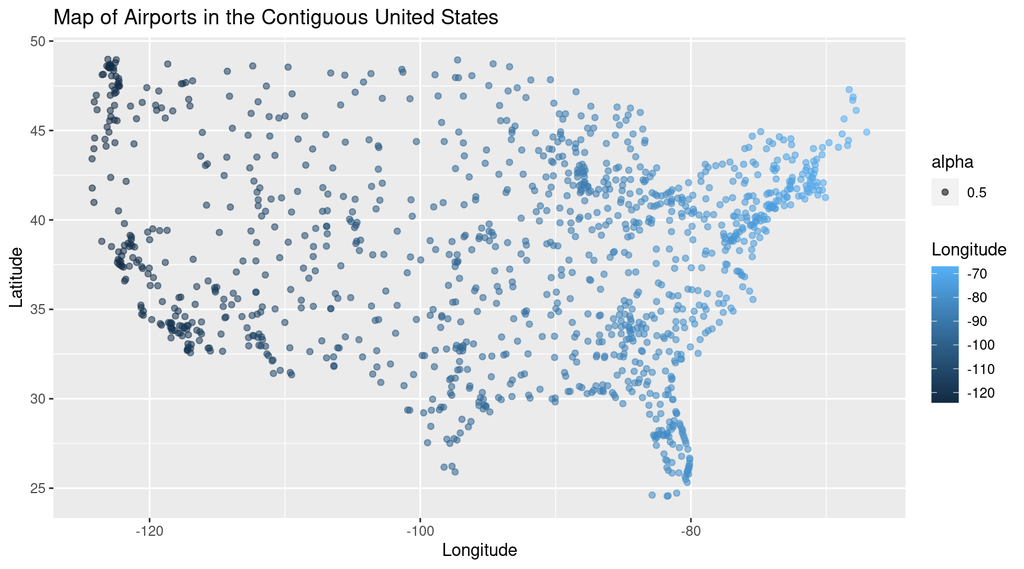

```r
airports %>%
  filter(lat <= 49.38447222222222 & lat >= 24.520833333333332,
         lon <= -66.94702777777778 & lon >= -124.77169444444445) %>%
  rename(Longitude = lon,
         Latitude = lat) %>%
  ggplot(mapping = aes(x = Longitude,
                       y = Latitude,
                       color = Longitude,
                       alpha = .5)) +
  geom_point() +
  labs(title = "Map of Airports in the Contiguous United States")
```

## Project Log

Used the following website for the sapply function: https://www.rdocumentation.org/packages/memisc/versions/0.99.31.7/topics/Sapply

## The Pledge

On my honor, I have neither given nor received any unacknowledged aid on this assignment.

Alex Wolff, 2024-04-13